# Google Trends Time Series Analysis

Forecasting Taco & S&P 500 Search Interest via SARIMA Models

Ducheng Tan, Alexander Beckford

STAT 335 · Spring 2026

```r
library(astsa)
library(ggplot2)
library(dplyr)
library(tidyr)
library(lubridate)
library(knitr)
library(kableExtra)
```

# 1 Overview

This project applies **Seasonal ARIMA (SARIMA) modeling** to Google Trends search interest data for three keywords — *Bitcoin*, *S&P 500*, and *Taco* — collected monthly from January 2021 through April 2026.

The core goals are:

1. Identify appropriate SARIMA models for the Taco and S&P 500 series using ACF/PACF diagnostics and information criteria (AIC/BIC).
2. Produce 4-step-ahead forecasts for January–April 2026 and validate them against the realized values from Google Trends.

All data are sourced from [Google Trends](https://trends.google.com/trends/) and represent **relative search interest** (0–100 scale) within the United States.

# 2 Data

```r
data <- read.csv(text = '
"Time","Taco","S.P.500","Bitcoin"
"2021-01-01",36,11,98
"2021-02-01",33,12,100
"2021-03-01",32,13,68
"2021-04-01",34,12,76
"2021-05-01",37,11,90
"2021-06-01",34,10,64
"2021-07-01",35,11,42
"2021-08-01",34,10,41
"2021-09-01",33,11,42
"2021-10-01",33,10,53
"2021-11-01",29,11,51
"2021-12-01",27,12,49
"2022-01-01",35,16,58
"2022-02-01",36,16,49
"2022-03-01",34,15,41
"2022-04-01",33,12,32
"2022-05-01",36,19,51
"2022-06-01",35,19,63
"2022-07-01",39,14,42
"2022-08-01",34,15,30
"2022-09-01",30,16,33
"2022-10-01",32,16,24
"2022-11-01",26,15,38
"2022-12-01",29,14,27
"2023-01-01",31,14,27
"2023-02-01",32,15,20
"2023-03-01",35,17,31
"2023-04-01",36,13,29
"2023-05-01",42,13,22
"2023-06-01",41,14,25
"2023-07-01",41,14,24
"2023-08-01",39,14,22
"2023-09-01",35,12,19
"2023-10-01",36,14,26
"2023-11-01",31,14,29
"2023-12-01",31,15,38
"2024-01-01",32,15,42
"2024-02-01",31,16,39
"2024-03-01",33,14,66
"2024-04-01",34,16,44
"2024-05-01",35,14,33
"2024-06-01",34,14,28
"2024-07-01",33,15,33
"2024-08-01",32,20,33
"2024-09-01",31,17,27
"2024-10-01",31,16,27
"2024-11-01",27,17,76
"2024-12-01",28,17,67
"2025-01-01",30,19,52
"2025-02-01",31,20,47
"2025-03-01",32,30,47
"2025-04-01",32,54,41
"2025-05-01",41,26,41
"2025-06-01",39,23,36
"2025-07-01",35,25,55
"2025-08-01",35,23,41
"2025-09-01",33,21,32
"2025-10-01",34,28,46
"2025-11-01",32,23,63
"2025-12-01",32,22,49
')


data_2026 <- read.csv(text = '
"Time","Taco","S.P.500","Bitcoin"
"2026-01-01",37,23,41
"2026-02-01",38,24,75
"2026-03-01",38,31,52
"2026-04-01",38,27,35
')


names(data)[names(data) == "S.P.500"]         <- "SP500"
names(data_2026)[names(data_2026) == "S.P.500"] <- "SP500"


bitcoin_ts    <- ts(data$Bitcoin,    start = c(2021, 1), frequency = 12)
sp500_ts      <- ts(data$SP500,      start = c(2021, 1), frequency = 12)
taco_ts       <- ts(data$Taco,       start = c(2021, 1), frequency = 12)

bitcoin_ts_26 <- ts(data_2026$Bitcoin, start = c(2026, 1), frequency = 12)
sp500_ts_26   <- ts(data_2026$SP500,   start = c(2026, 1), frequency = 12)
taco_ts_26    <- ts(data_2026$Taco,    start = c(2026, 1), frequency = 12)
```

## 2.1 Time Series Plot

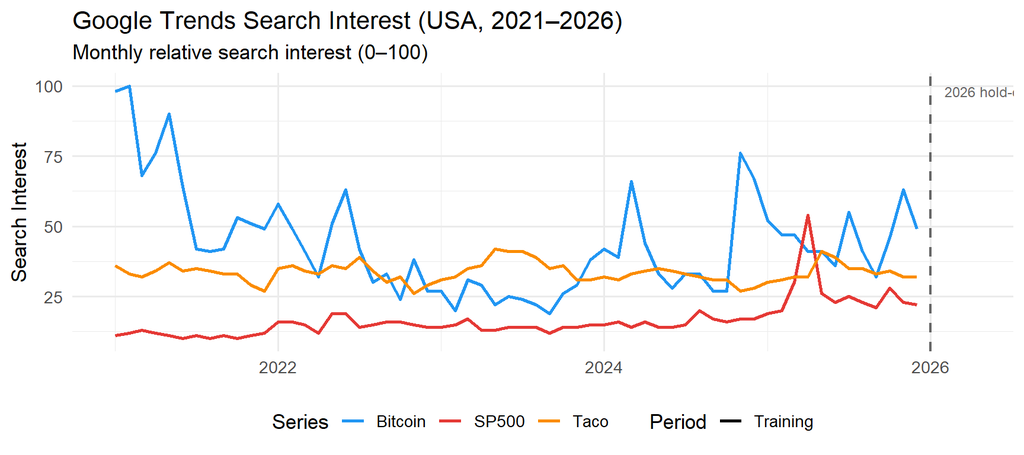

```r
bitcoin_all <- c(data$Bitcoin, data_2026$Bitcoin)
sp500_all   <- c(data$SP500,   data_2026$SP500)
taco_all    <- c(data$Taco,    data_2026$Taco)

dates <- seq(as.Date("2021-01-01"), by = "month", length.out = length(bitcoin_all))

trends_long <- data.frame(
  Date    = dates,
  Bitcoin = bitcoin_all,
  SP500   = sp500_all,
  Taco    = taco_all
) |>
  pivot_longer(cols = -Date, names_to = "Series", values_to = "Interest") |>
  mutate(Period = ifelse(Date >= as.Date("2026-01-01"), "Hold-out (2026)", "Training"))

ggplot(trends_long, aes(x = Date, y = Interest, color = Series, linetype = Period)) +
  geom_line(linewidth = 0.9) +
  geom_vline(xintercept = as.numeric(as.Date("2026-01-01")),
             linetype = "dashed", color = "gray40", linewidth = 0.8) +
  annotate("text", x = as.Date("2026-02-01"), y = 98,
           label = "2026 hold-out", size = 3.2, color = "gray40", hjust = 0) +
  scale_color_manual(values = c(Bitcoin = "#2196F3", SP500 = "#E53935", Taco = "#FB8C00")) +
  scale_linetype_manual(values = c("Training" = "solid", "2026" = "dashed")) +
  labs(
    title    = "Google Trends Search Interest (USA, 2021–2026)",
    subtitle = "Monthly relative search interest (0–100)",
    x = NULL, y = "Search Interest",
    color = "Series", linetype = "Period"
  ) +
  theme_minimal(base_size = 13) +
  theme(legend.position = "bottom")
```

The three series exhibit different behavior:

- **Bitcoin** shows high volatility with spikes tied to major crypto events.
- **S&P 500** follows a smoother upward trend with mild seasonality.
- **Taco** displays stable, recurring annual seasonality — peaking around Taco Tuesday peaks and Mexican holidays (Cinco de Mayo).

# 3 Model Specification

In this report we assume that all models follow the general **SARIMA** form:

$$\Phi_P(B^s)\,\phi(B)\,\nabla_s^D\,\nabla^d\, x_t
= \alpha + \Theta_Q(B^s)\,\theta(B)\,w_t,
\quad w_t \overset{\text{iid}}{\sim} \mathcal{N}(0,\,\sigma_w^2)$$

denoted **ARIMA$(p,d,q)\times(P,D,Q)_s$**, where:

| Symbol | Meaning |
| --- | --- |
| $\phi(B)$, $\theta(B)$ | Ordinary AR/MA polynomials (orders $p$, $q$) |
| $\Phi_P(B^s)$, $\Theta_Q(B^s)$ | Seasonal AR/MA polynomials (orders $P$, $Q$) |
| $\nabla^d = (1-B)^d$ | Ordinary differencing |
| $\nabla_s^D = (1-B^s)^D$ | Seasonal differencing |

# 4 Model Fitting

## 4.1 Taco ($T_t$)

### 4.1.1 Diagnostics

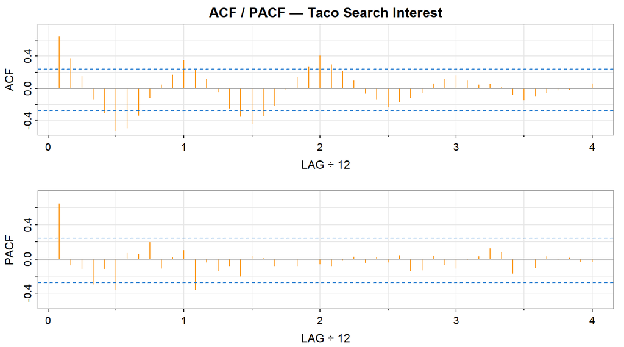

```
##      [,1]  [,2]  [,3]  [,4]  [,5]  [,6]  [,7]  [,8]  [,9] [,10] [,11] [,12]
## ACF  0.65  0.38  0.15 -0.14 -0.30 -0.52 -0.49 -0.33 -0.11  0.05  0.17  0.35
## PACF 0.65 -0.07 -0.11 -0.29 -0.11 -0.36  0.07  0.06  0.20 -0.11  0.02  0.10
##      [,13] [,14] [,15] [,16] [,17] [,18] [,19] [,20] [,21] [,22] [,23] [,24]
## ACF   0.23  0.12 -0.04 -0.24 -0.35 -0.43 -0.34 -0.21 -0.01  0.14  0.27  0.40
## PACF -0.36 -0.03 -0.14 -0.08 -0.20  0.04  0.01 -0.08  0.00 -0.08  0.00 -0.06
##      [,25] [,26] [,27] [,28] [,29] [,30] [,31] [,32] [,33] [,34] [,35] [,36]
## ACF   0.30  0.21  0.10 -0.06 -0.13 -0.23 -0.17 -0.11 -0.05  0.06  0.12  0.16
## PACF -0.08 -0.01  0.03 -0.04  0.02 -0.04  0.05 -0.14 -0.13  0.04 -0.07 -0.11
##      [,37] [,38] [,39] [,40] [,41] [,42] [,43] [,44] [,45] [,46] [,47] [,48]
## ACF   0.10  0.05  0.06  0.02 -0.08 -0.14 -0.09 -0.05 -0.02 -0.01  0.01  0.06
## PACF -0.01  0.03  0.13  0.08 -0.17  0.00 -0.10  0.03 -0.01  0.02 -0.03 -0.03
```

```r
acf2(taco_ts, col = "#FB8C00", main = "ACF / PACF — Taco Search Interest")
```

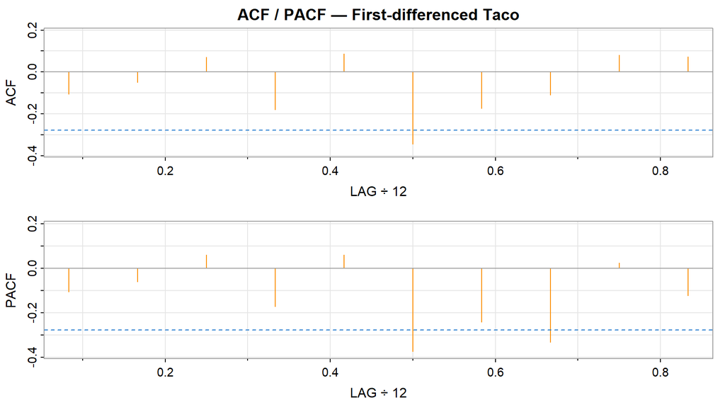

```
##       [,1]  [,2] [,3]  [,4] [,5]  [,6]  [,7]  [,8] [,9] [,10]
## ACF  -0.11 -0.05 0.07 -0.18 0.09 -0.34 -0.17 -0.11 0.08  0.07
## PACF -0.11 -0.06 0.06 -0.17 0.06 -0.37 -0.24 -0.33 0.02 -0.12
```

```r
acf2(diff(taco_ts), col = "#FB8C00",
     main = "ACF / PACF — First-differenced Taco")
```

The raw series shows a slowly decaying ACF with seasonal spikes at lags 12, 24 — consistent with annual seasonality. After differencing, the ACF cuts off, suggesting a low-order MA structure.

### 4.1.2 Candidate Models

```r
fit_t1 <- sarima(taco_ts, p=1, d=0, q=0, P=0, D=1, Q=0, S=12, details=FALSE)
```

```
## <><><><><><><><><><><><><><>
##
## Coefficients:
##          Estimate     SE t.value p.value
## ar1        0.7440 0.0932  7.9853  0.0000
## constant   0.0275 0.1114  0.2464  0.8065
##
## sigma^2 estimated as 6.291192 on 46 degrees of freedom
##
## AIC = 4.818824  AICc = 4.82438  BIC = 4.935774
##
```

```r
fit_t2 <- sarima(taco_ts, p=0, d=0, q=1, P=0, D=1, Q=1, S=12, details=FALSE)
```

```
## <><><><><><><><><><><><><><>
##
## Coefficients:
##          Estimate     SE t.value p.value
## ma1        0.6661 0.0973  6.8434  0.0000
## sma1      -1.0000 0.6786 -1.4737  0.1475
## constant  -0.0021 0.0237 -0.0893  0.9293
##
## sigma^2 estimated as 3.646854 on 45 degrees of freedom
##
## AIC = 4.71283  AICc = 4.724194  BIC = 4.868764
##
```

```r
fit_t3 <- sarima(taco_ts, p=1, d=0, q=0, P=0, D=1, Q=1, S=12, details=FALSE)
```

```
## <><><><><><><><><><><><><><>
##
## Coefficients:
##          Estimate     SE t.value p.value
## ar1        0.6695 0.1103  6.0681  0.0000
## sma1      -0.6907 0.3053 -2.2626  0.0285
## constant  -0.0004 0.0427 -0.0100  0.9921
##
## sigma^2 estimated as 4.299897 on 45 degrees of freedom
##
## AIC = 4.630979  AICc = 4.642342  BIC = 4.786912
##
```

```r
fit_t4 <- sarima(taco_ts, p=1, d=0, q=1, P=0, D=1, Q=1, S=12, details=FALSE)
```

```
## <><><><><><><><><><><><><><>
##
## Coefficients:
##          Estimate     SE t.value p.value
## ar1        0.6693 0.2130  3.1422  0.0030
## ma1        0.0003 0.3197  0.0009  0.9993
## sma1      -0.6906 0.3084 -2.2396  0.0302
## constant  -0.0004 0.0428 -0.0100  0.9921
##
## sigma^2 estimated as 4.300112 on 44 degrees of freedom
##
## AIC = 4.672645  AICc = 4.692025  BIC = 4.867562
##
```

```
## <><><><><><><><><><><><><><>
##
## Coefficients:
##       Estimate     SE t.value p.value
## ar1     0.6589 0.0969  6.8007  0.0000
## sar1    0.9354 0.1182  7.9145  0.0000
## sma1   -0.6580 0.3200 -2.0562  0.0444
## xmean  33.6822 1.6806 20.0424  0.0000
##
## sigma^2 estimated as 4.155312 on 56 degrees of freedom
##
## AIC = 4.583921  AICc = 4.596042  BIC = 4.758449
##
```

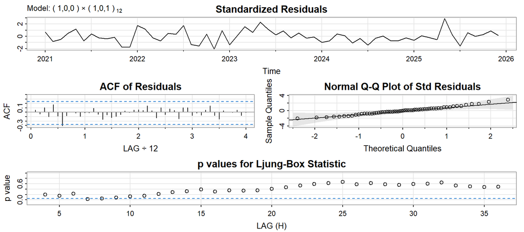

[output not shown]

```r
fit_t5 <- sarima(taco_ts, p=1, d=0, q=0, P=1, D=0, Q=1, S=12, details=TRUE) # Winner
```

### 4.1.3 Selected Model

The **ARIMA$(1,0,0)\times(1,0,1)_{12}$** achieves the lowest AIC/BIC and passes residual diagnostics (Ljung-Box p-values > 0.05 throughout, well-behaved Q-Q plot).

The fitted model for $T_t$ is:

$$(1 - \phi_1 B)(1 - \Phi_1 B^{12})\,T_t
= \alpha + (1 + \Theta_1 B^{12})\,w_t,
\quad w_t \sim \mathcal{N}(0,\; \hat{\sigma}_w^2 = 4.155)$$

## 4.2 S&P 500 ($S_t$)

### 4.2.1 Diagnostics

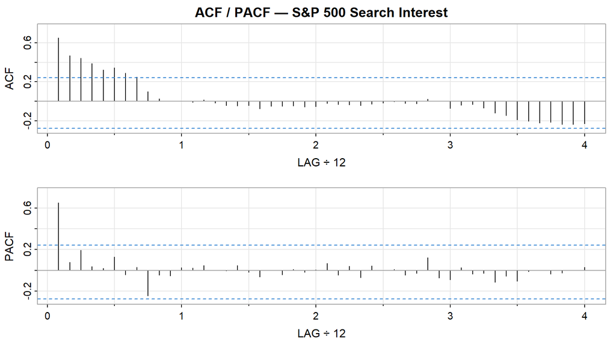

```
##      [,1] [,2] [,3] [,4] [,5] [,6]  [,7] [,8]  [,9] [,10] [,11] [,12] [,13]
## ACF  0.65 0.47 0.44 0.39 0.32 0.34  0.29 0.25  0.10  0.03  0.00  0.00 -0.01
## PACF 0.65 0.08 0.19 0.04 0.02 0.13 -0.04 0.03 -0.24 -0.05 -0.05  0.03  0.02
##      [,14] [,15] [,16] [,17] [,18] [,19] [,20] [,21] [,22] [,23] [,24] [,25]
## ACF   0.02 -0.02 -0.04 -0.05 -0.04 -0.07 -0.05 -0.05 -0.05 -0.06 -0.05 -0.02
## PACF  0.05  0.00  0.00  0.05 -0.02 -0.06  0.00 -0.04  0.01 -0.02  0.01  0.07
##      [,26] [,27] [,28] [,29] [,30] [,31] [,32] [,33] [,34] [,35] [,36] [,37]
## ACF  -0.03 -0.04 -0.04 -0.03 -0.02  0.00 -0.02 -0.03  0.02  0.01 -0.07 -0.04
## PACF -0.04  0.04 -0.07  0.04  0.00  0.01 -0.04 -0.03  0.12 -0.07 -0.09  0.03
##      [,38] [,39] [,40] [,41] [,42] [,43] [,44] [,45] [,46] [,47] [,48]
## ACF  -0.03 -0.07 -0.12 -0.15 -0.19 -0.20 -0.22 -0.21 -0.24 -0.23 -0.23
## PACF -0.03 -0.03 -0.12 -0.06 -0.10 -0.01  0.00 -0.04 -0.03  0.00  0.03
```

```r
acf2(sp500_ts, main = "ACF / PACF — S&P 500 Search Interest")
```

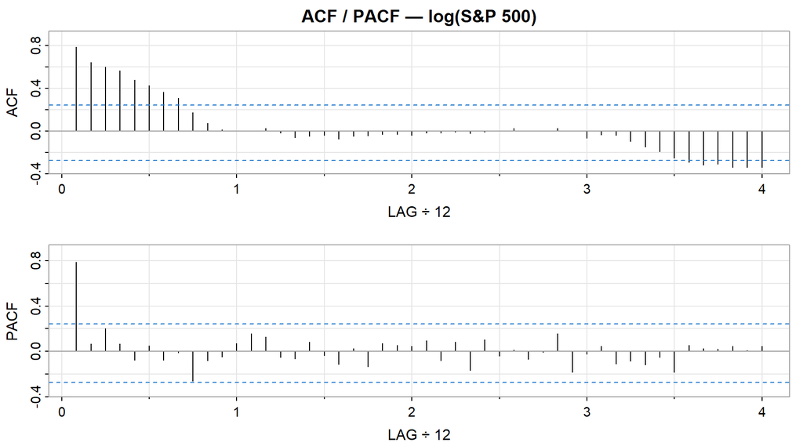

```
##      [,1] [,2] [,3] [,4]  [,5] [,6]  [,7]  [,8]  [,9] [,10] [,11] [,12] [,13]
## ACF  0.79 0.65  0.6 0.56  0.48 0.43  0.37  0.31  0.17  0.07  0.01  0.00  0.00
## PACF 0.79 0.07  0.2 0.07 -0.08 0.05 -0.08 -0.01 -0.26 -0.08 -0.05  0.07  0.15
##      [,14] [,15] [,16] [,17] [,18] [,19] [,20] [,21] [,22] [,23] [,24] [,25]
## ACF   0.03 -0.02 -0.06 -0.05 -0.04 -0.07 -0.05 -0.05 -0.03 -0.03 -0.04 -0.02
## PACF  0.13 -0.05 -0.06  0.08 -0.04 -0.12  0.02 -0.14  0.07  0.05  0.04  0.09
##      [,26] [,27] [,28] [,29] [,30] [,31] [,32] [,33] [,34] [,35] [,36] [,37]
## ACF  -0.02 -0.01 -0.02 -0.01  0.00  0.03  0.01  0.00  0.03  0.00 -0.06 -0.04
## PACF -0.08  0.08 -0.17  0.10 -0.04  0.01 -0.07 -0.01  0.16 -0.18 -0.03  0.04
##      [,38] [,39] [,40] [,41] [,42] [,43] [,44] [,45] [,46] [,47] [,48]
## ACF  -0.04 -0.10 -0.15 -0.19 -0.25 -0.29 -0.32 -0.31 -0.34 -0.34 -0.34
## PACF -0.11 -0.09 -0.12 -0.05 -0.19  0.05  0.02  0.02  0.04  0.01  0.04
```

```r
acf2(log(sp500_ts), main = "ACF / PACF — log(S&P 500)")
```

The log transform substantially stabilizes variance. The PACF of $\log(S_t)$ cuts off near lag 1, while the ACF decays slowly — suggesting a non-stationary process best handled with $d=1$ differencing.

### 4.2.2 Candidate Models

```r
# Raw series
fit_s1 <- sarima(sp500_ts, p=0, d=1, q=2, details=FALSE)
```

```
## <><><><><><><><><><><><><><>
##
## Coefficients:
##          Estimate     SE t.value p.value
## ma1       -0.4781 0.1259 -3.7984  0.0004
## ma2       -0.3524 0.1360 -2.5922  0.0121
## constant   0.2472 0.1196  2.0666  0.0434
##
## sigma^2 estimated as 22.44505 on 56 degrees of freedom
##
## AIC = 6.102389  AICc = 6.109785  BIC = 6.243239
##
```

```r
fit_s2 <- sarima(sp500_ts, p=2, d=1, q=0, details=FALSE)
```

```
## <><><><><><><><><><><><><><>
##
## Coefficients:
##          Estimate     SE t.value p.value
## ar1       -0.3275 0.1224 -2.6757  0.0098
## ar2       -0.3257 0.1215 -2.6801  0.0096
## constant   0.2039 0.3963  0.5145  0.6090
##
## sigma^2 estimated as 24.81455 on 56 degrees of freedom
##
## AIC = 6.189768  AICc = 6.197164  BIC = 6.330618
##
```

```r
fit_s3 <- sarima(sp500_ts, p=2, d=1, q=2, details=FALSE)
```

```
## <><><><><><><><><><><><><><>
##
## Coefficients:
##          Estimate     SE t.value p.value
## ar1       -0.0055 0.5328 -0.0102  0.9919
## ar2        0.1592 0.2860  0.5567  0.5800
## ma1       -0.5022 0.5154 -0.9743  0.3342
## ma2       -0.4978 0.5119 -0.9724  0.3352
## constant   0.2361 0.0589  4.0078  0.0002
##
## sigma^2 estimated as 21.32593 on 54 degrees of freedom
##
## AIC = 6.15586  AICc = 6.175048  BIC = 6.367135
##
```

```r
# Log-transformed series
fit_s4 <- sarima(log(sp500_ts), p=0, d=0, q=8, details=FALSE)
```

```
## <><><><><><><><><><><><><><>
##
## Coefficients:
##       Estimate     SE t.value p.value
## ma1     0.5621 0.3427  1.6404  0.1071
## ma2     0.2404 0.1526  1.5755  0.1213
## ma3     0.2017 0.1202  1.6781  0.0994
## ma4     0.5445 0.2483  2.1927  0.0329
## ma5     0.4069 0.1702  2.3904  0.0206
## ma6     0.6604 0.3326  1.9856  0.0525
## ma7     0.3665 0.1865  1.9648  0.0549
## ma8     0.5156 0.3572  1.4437  0.1549
## xmean   2.7455 0.0887 30.9445  0.0000
##
## sigma^2 estimated as 0.02597834 on 51 degrees of freedom
##
## AIC = -0.332202  AICc = -0.272202  BIC = 0.01685544
##
```

```
## <><><><><><><><><><><><><><>
##
## Coefficients:
##          Estimate     SE t.value p.value
## ma1       -0.3382 0.1237 -2.7329  0.0084
## ma2       -0.3260 0.1287 -2.5327  0.0141
## constant   0.0135 0.0079  1.7032  0.0941
##
## sigma^2 estimated as 0.02926085 on 56 degrees of freedom
##
## AIC = -0.5493104  AICc = -0.5419144  BIC = -0.4084604
##
```

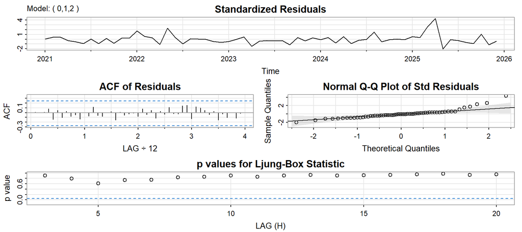

```r
fit_s5 <- sarima(log(sp500_ts), p=0, d=1, q=2, details=TRUE) # Winner
```

```r
fit_s6 <- sarima(log(sp500_ts), p=0, d=0, q=8, P=0, D=0, Q=1, S=42, details=FALSE)
```

```
## <><><><><><><><><><><><><><>
##
## Coefficients:
##       Estimate     SE t.value p.value
## ma1     0.5475 0.2717  2.0146  0.0493
## ma2     0.2229 0.1939  1.1499  0.2557
## ma3     0.2194 0.1199  1.8298  0.0733
## ma4     0.5807 0.1803  3.2214  0.0022
## ma5     0.3908 0.2006  1.9479  0.0571
## ma6     0.6267 0.2761  2.2695  0.0276
## ma7     0.3582 0.1869  1.9169  0.0610
## ma8     0.5609 0.2145  2.6146  0.0118
## sma1   -0.2473 0.2242 -1.1028  0.2754
## xmean   2.7543 0.0793 34.7274  0.0000
##
## sigma^2 estimated as 0.02368363 on 50 degrees of freedom
##
## AIC = -0.3226523  AICc = -0.2478224  BIC = 0.06131087
##
```

S&P 500 Model Comparison

| Model | AIC | BIC |
| --- | --- | --- |
| ARIMA(0,1,2) — raw | 6.1024 | 6.2432 |
| ARIMA(2,1,0) — raw | 6.1898 | 6.3306 |
| ARIMA(2,1,2) — raw | 6.1559 | 6.3671 |
| ARIMA(0,0,8) — log | -0.3322 | 0.0169 |
| ARIMA(0,1,2) — log | -0.5493 | -0.4085 |
| SARIMA(0,0,8)×(0,0,1)₄₂ — log | -0.3227 | 0.0613 |

### 4.2.3 Selected Model

**ARIMA$(0,1,2)$ on $\log(S_t)$** balances fit quality, parsimony, and interpretability. The log transform implies a multiplicative error structure — appropriate for a proportional search-interest index.

# 5 Forecasting

## 5.1 Theoretical Framework

Expanding the Taco ARIMA$(1,0,0)\times(1,0,1)_{12}$ gives:

$$T_t = \alpha + \phi_1 T_{t-1} + \Phi_1 T_{t-12} - \phi_1\Phi_1 T_{t-13}
+ w_t + \Theta_1 w_{t-12}$$

The $m$-step-ahead forecast $T_{n+m}^n = \mathbb{E}[T_{n+m} \mid T_1,\ldots,T_n]$ is obtained by replacing future noise terms with 0:

$$T_{n+m}^n = \alpha + \phi_1\,T_{n+m-1}^n + \Phi_1\,T_{n+m-12}
- \phi_1\Phi_1\,T_{n+m-13} + \Theta_1\,w_{n+m-12}$$

### 5.1.1 Taco ($T_t$) — ARIMA$(1,0,0)\times(1,0,1)_{12}$

Expanding the seasonal operators gives:

$$T_t = \alpha + \phi_1 T_{t-1} + \Phi_1 T_{t-12} - \phi_1\Phi_1 T_{t-13}
+ w_t + \Theta_1 w_{t-12}$$

The $m$-step-ahead forecast $T_{n+m}^n = \mathbb{E}[T_{n+m} \mid T_1,\ldots,T_n]$ replaces all future noise terms with zero ($w_{n+j}^n = 0,\; j > 0$):

$$T_{n+m}^n = \alpha + \phi_1\,T_{n+m-1}^n + \Phi_1\,T_{n+m-12}
- \phi_1\Phi_1\,T_{n+m-13} + \Theta_1\,w_{n+m-12}$$

The mean-squared prediction error for $m \leq 12$ is:

$$p_{n+m}^n = \sigma_w^2 \sum_{j=0}^{m-1} \phi_1^{2j}
= \sigma_w^2 \left(\frac{1 - \phi_1^{2m}}{1 -
\phi_1^2}\right)$$

### 5.1.2 S&P 500 ($L_t = \log S_t$) — ARIMA$(0,1,2)$

Let $L_t = \log(S_t)$. The ARIMA$(0,1,2)$ model is:

$$(1 - B)\,L_t = \alpha + (1 + \theta_1 B + \theta_2 B^2)\,w_t,
\quad w_t \overset{\text{iid}}{\sim} \mathcal{N}(0,\,\sigma_w^2)$$

Expanding $(1-B)L_t = L_t - L_{t-1}$ gives the explicit form:

$$L_t = \alpha + L_{t-1} + w_t + \theta_1\,w_{t-1} + \theta_2\,w_{t-2}$$

Taking the conditional expectation $L_{n+m}^n = \mathbb{E}[L_{n+m} \mid L_1,\ldots,L_n]$ and using $w_{n+j}^n = 0$ for $j > 0$, the forecasts step through as:

$$L_{n+m}^n =
\begin{cases}
\alpha + L_n + \theta_1\,w_n + \theta_2\,w_{n-1} & m = 1 \\[4pt]
\alpha + L_{n+1}^n + \theta_2\,w_n & m = 2 \\[4pt]
\alpha + L_{n+m-1}^n & m \geq 3
\end{cases}$$

For $m \geq 3$ the forecast increments by $\alpha$ each step — a linear drift — because all MA error terms have been exhausted.

To derive the MSPE, write $L_t$ as an infinite MA via $(1-B)^{-1} = \sum_{k=0}^{\infty} B^k$:

$$L_t = \sum_{j=0}^{\infty} \psi_j\, w_{t-j}, \qquad
\psi(B) = (1 + B + B^2 + \cdots)(1 + \theta_1 B + \theta_2 B^2)$$

Collecting terms by power of $B$ gives the $\psi$-weights:

$$\psi_0 = 1, \qquad \psi_1 = 1 + \theta_1, \qquad
\psi_j = 1 + \theta_1 + \theta_2 \quad \text{for } j \geq 2$$

The $m$-step-ahead forecast error is $e_{n+m}^n = \sum_{j=0}^{m-1} \psi_j\, w_{n+m-j}$, so the MSPE is:

$$p_{n+m}^n = \sigma_w^2 \sum_{j=0}^{m-1} \psi_j^2 =
\sigma_w^2 \Big[
1
+ (1+\theta_1)^2 \cdot \mathbf{1}_{m \geq 2}
+ (m-2)(1+\theta_1+\theta_2)^2 \cdot \mathbf{1}_{m \geq 3}
\Big]$$

Note that $p_{n+m}^n$ grows **linearly** in $m$ for large $m$ (versus the geometric growth from the stationary Taco model), reflecting the non-stationary $d=1$ differencing.

## 5.2 Forecast Plots

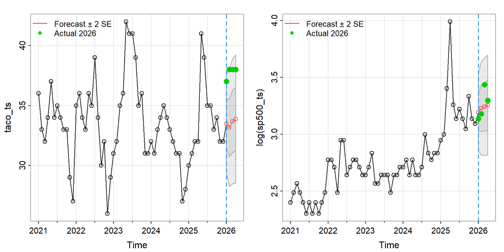

```r
par(mfrow = c(1, 2))

fcast_taco <- sarima.for(
  taco_ts, n.ahead = 4,
  p=1, d=0, q=0, P=1, D=0, Q=1, S=12
)
abline(v = 2026, col = "dodgerblue", lty = 2, lwd = 1.5)
points(taco_ts_26, pch = 16, col = "green3", cex = 1.3)
legend("topleft",
       legend = c("Forecast ± 2 SE", "Actual 2026"),
       pch    = c(NA, 16),
       lty    = c(1, NA),
       col    = c("red", "green3"),
       cex    = 0.85,
       bty    = "n")
title(sub = "Taco — ARIMA(1,0,0)×(1,0,1)₁₂", cex.sub = 0.9)

# S&P 500 Forecast
fcast_sp <- sarima.for(
  log(sp500_ts), n.ahead = 4,
  p=0, d=1, q=2
)
abline(v = 2026, col = "dodgerblue", lty = 2, lwd = 1.5)
points(log(sp500_ts_26), pch = 16, col = "green3", cex = 1.3)
legend("topleft",
       legend = c("Forecast ± 2 SE", "Actual 2026"),
       pch    = c(NA, 16),
       lty    = c(1, NA),
       col    = c("red", "green3"),
       cex    = 0.85,
       bty    = "n")
title(sub = "log(S&P 500) — ARIMA(0,1,2)", cex.sub = 0.9)
```

## 5.3 Forecast vs. Actuals

```r
predicted  <- fcast_taco$pred
upper95    <- fcast_taco$pred + 2 * fcast_taco$se
lower95    <- fcast_taco$pred - 2 * fcast_taco$se
actual     <- data_2026$Taco

comparison <- data.frame(
  Month     = data_2026$Time,
  Actual    = actual,
  Predicted = round(as.numeric(predicted), 2),
  Lower95   = round(as.numeric(lower95),   2),
  Upper95   = round(as.numeric(upper95),   2),
  Error     = round(actual - as.numeric(predicted), 2),
  In_CI     = ifelse(actual >= as.numeric(lower95) &
                     actual <= as.numeric(upper95), "✓ Yes", "✗ No")
)

kable(comparison,
      col.names = c("Month", "Actual", "Predicted", "Lower 95%",
                    "Upper 95%", "Error", "Within CI?"),
      caption   = "Taco: 4-Step-Ahead Forecast vs. Realized Values") |>
  kable_styling(bootstrap_options = c("striped", "hover"), full_width = FALSE) |>
  column_spec(7, bold = TRUE,
              color = ifelse(comparison$In_CI == "Yes", "green", "red"))
```

Taco: 4-Step-Ahead Forecast vs. Realized Values

| Month | Actual | Predicted | Lower 95% | Upper 95% | Error | Within CI? |
| --- | --- | --- | --- | --- | --- | --- |
| 2026-01-01 | 37 | 33.48 | 29.39 | 37.57 | 3.52 | ✓ Yes |
| 2026-02-01 | 38 | 33.16 | 28.26 | 38.05 | 4.84 | ✓ Yes |
| 2026-03-01 | 38 | 33.68 | 28.47 | 38.88 | 4.32 | ✓ Yes |
| 2026-04-01 | 38 | 33.88 | 28.55 | 39.22 | 4.12 | ✓ Yes |

All four realized values fall within the 95% forecast intervals, though they consistently sit near the upper bound — suggesting the model slightly underestimates recent Taco search interest, possibly due to a structural uptick not captured in the training window.

# 6 Conclusion

| Series | Best Model |
| --- | --- |
| Taco ($T_t$) | ARIMA$(1,0,0)\times(1,0,1)_{12}$ |
| $\log$ S&P 500 ($L_t$) | ARIMA$(0,1,2)$ |

Both models successfully capture the dominant structure of their respective series. The 4-step-ahead forecasts for January–April 2026 contain all realized values within the 95% confidence intervals, demonstrating reasonable out-of-sample predictive performance.

**Limitations & future work:**

- Bitcoin was excluded from forecasting due to its high volatility and irregular spike pattern, which is ill-suited to SARIMA assumptions.
- Incorporating exogenous regressors (e.g., CPI, social media sentiment) via SARIMAX could improve S&P 500 forecasts.
- Longer holdout periods would provide stronger validation.

# 7 References

1. Shumway, R. H., & Stoffer, D. S. (2019). *Time Series: A Data Analysis Approach Using R.* Chapman and Hall/CRC.
2. Google Trends. https://trends.google.com/trends/ (Data accessed: April 20, 2026).